# PM 566 Homework 3

Author

Uma Agarwal

```r
library(tidyverse)
library(tidytext)
library(textdata)

pubmed <- read_csv("https://raw.githubusercontent.com/USCbiostats/data-science-data/refs/heads/master/03_pubmed/pubmed.csv")
```

#1

For the “covid” search term, there are 981 abstracts. There are 376 abstracts for “cystic fibrosis”, 317 for “meningitis”, 780 for “preeclampsia”, and 787 for “prostate cancer”.

When tokenized, there are at least 1000 tokens which are just numerical figures.

For each search term, the top 5 tokens include words such as “the”, “and”, “of”, etc. The “covid” term additionally includes “covid” and “19”, and the “prostate cancer” term additionally includes “prostate” and “cancer”. Aside from these, the top 5 tokens don’t provide much information on the abstracts.

```r
# number of abstracts per term
table(pubmed$term)
```

```
          covid cystic fibrosis      meningitis    preeclampsia prostate cancer
            981             376             317             780             787
```

```r
# tokenize into single words
pubmed %>%
  unnest_tokens(word, abstract) %>%
  count(word)
```

```
# A tibble: 20,567 × 2
   word        n
   <chr>   <int>
 1 0          92
 2 0,00001     2
 3 0,02        1
 4 0,05        1
 5 0,2,1       2
 6 0.0         2
 7 0.000      12
 8 0.00001     2
 9 0.0001     42
10 0.0002      4
# ℹ 20,557 more rows
```

```r
# top 5 tokens per term
pubmed %>%
  unnest_tokens(word, abstract) %>%
  count(term, word, sort = T) %>%
  group_by(term) %>%
  slice_max(n, n = 5)
```

```
# A tibble: 25 × 3
# Groups:   term [5]
   term            word      n
   <chr>           <chr> <int>
 1 covid           the    9741
 2 covid           of     7668
 3 covid           covid  7275
 4 covid           19     7035
 5 covid           and    6861
 6 cystic fibrosis the    2677
 7 cystic fibrosis of     2304
 8 cystic fibrosis and    1777
 9 cystic fibrosis in     1497
10 cystic fibrosis to     1011
# ℹ 15 more rows
```

#2

Removing stopwords improves the resulting top 5 tokens per term. Now, the top 5 words for each term are clearly associated with the term, such as “pregnancy” for “preeclampsia”.

```r
# remove stopwords
pubmed %>%
  unnest_tokens(word, abstract) %>%
  anti_join(stop_words, by = "word") %>%
  count(term, word, sort = T) %>%
  group_by(term) %>%
  slice_max(n, n = 5)
```

```
# A tibble: 25 × 3
# Groups:   term [5]
   term            word         n
   <chr>           <chr>    <int>
 1 covid           covid     7275
 2 covid           19        7035
 3 covid           patients  2293
 4 covid           disease    943
 5 covid           pandemic   800
 6 cystic fibrosis fibrosis   867
 7 cystic fibrosis cystic     862
 8 cystic fibrosis cf         625
 9 cystic fibrosis patients   586
10 cystic fibrosis disease    400
# ℹ 15 more rows
```

#3

The bigrams are somewhat informative, including phrases such as “covid 19” and “prostate cancer”. But many of the bigrams are made of only stopwords, like “of the”, which takes away from the overall informativeness.

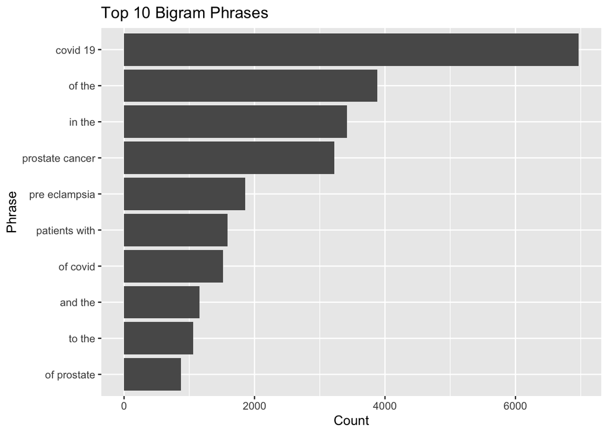

```r
# bigrams
top_10_ngrams <- pubmed %>%
  unnest_ngrams(ngram, abstract, 2) %>%
  count(ngram, sort = T) %>%
  top_n(10, n)

top_10_ngrams %>%
  ggplot(aes(x = n, y = reorder(ngram, n))) +
  geom_col() +
  labs(x = "Count", y = "Phrase",
       title = "Top 10 Bigram Phrases")
```

#4

Compared to the results of Question 1 and 2, the top 5 words here are much more specific and informative of each search term. Words shared by all 5 search terms, such as “patient” and “disease” are now eliminated, revealing further differences between each search term.

```r
# tf-idf
pubmed %>%
  unnest_tokens(word, abstract) %>%
  group_by(term) %>%
  count(word, sort = T) %>%
  bind_tf_idf(word, term, n) %>%
  group_by(term) %>%
  slice_max(tf_idf, n = 5)
```

```
# A tibble: 25 × 6
# Groups:   term [5]
   term            word            n      tf   idf  tf_idf
   <chr>           <chr>       <int>   <dbl> <dbl>   <dbl>
 1 covid           covid        7275 0.0371  1.61  0.0597
 2 covid           pandemic      800 0.00408 1.61  0.00657
 3 covid           coronavirus   647 0.00330 1.61  0.00531
 4 covid           sars          372 0.00190 1.61  0.00305
 5 covid           cov           334 0.00170 1.61  0.00274
 6 cystic fibrosis cf            625 0.0127  0.916 0.0117
 7 cystic fibrosis fibrosis      867 0.0176  0.511 0.00901
 8 cystic fibrosis cystic        862 0.0175  0.511 0.00896
 9 cystic fibrosis cftr           86 0.00175 1.61  0.00282
10 cystic fibrosis sweat          83 0.00169 1.61  0.00272
# ℹ 15 more rows
```

#5

The top sentiment for “covid”, “cystic fibrosis”, and “preeclampsia” is “positive”. It is is “negative” for the other two search terms.

When “positive” and “negative” are filtered out, the sentiments change to “fear”, “disgust”, and “anticipation”, which seem, more or less, to make sense given that these are serious diseases.

```r
# sentiment analysis w/ NRC lexicon
pubmed %>%
  unnest_tokens(word, abstract) %>%
  inner_join(get_sentiments("nrc")) %>%
  count(term, sentiment, sort = T) %>%
  group_by(term) %>%
  slice_max(n, n = 1)
```

```
# A tibble: 5 × 3
# Groups:   term [5]
  term            sentiment     n
  <chr>           <chr>     <int>
1 covid           positive   9874
2 cystic fibrosis positive   2747
3 meningitis      negative   2109
4 preeclampsia    positive   8014
5 prostate cancer negative   8918
```

```r
# filter out "positive" and "negative"
pubmed %>%
  unnest_tokens(word, abstract) %>%
  inner_join(get_sentiments("nrc") %>%
               filter(!sentiment %in% c("positive", "negative"))) %>%
  count(term, sentiment, sort = T) %>%
  group_by(term) %>%
  slice_max(n, n = 1)
```

```
# A tibble: 5 × 3
# Groups:   term [5]
  term            sentiment        n
  <chr>           <chr>        <int>
1 covid           fear          7730
2 cystic fibrosis disgust       1714
3 meningitis      fear          1510
4 preeclampsia    anticipation  4780
5 prostate cancer fear          8118
```

#6

For most search terms, the median average sentiment hovers just under 0, however, for “cystic fibrosis”, the average sentiment is instead positive. Additionally, “prostate cancer” has a visibly lower variance despite having the 2nd largest sample size out of the 5 terms.

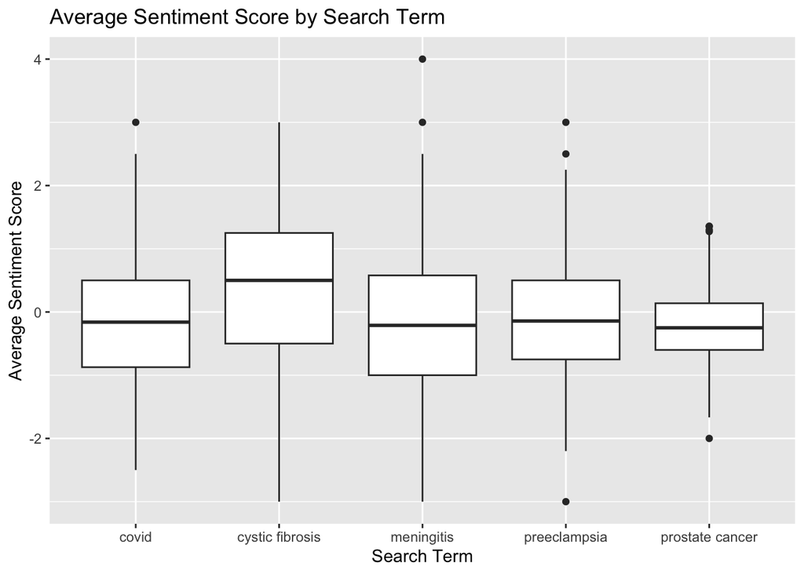

```r
# sentiment analysis with afinn lexicon
pubmed_sentiments <- pubmed %>%
  mutate(abstract_id = row_number()) %>%
  unnest_tokens(word, abstract) %>%
  inner_join(get_sentiments("afinn")) %>%
  group_by(term, abstract_id) %>%
  summarise(avg_sentiment = mean(value), .groups = "drop")
# boxplots
pubmed_sentiments %>%
  ggplot(aes(x = term, y = avg_sentiment)) +
  geom_boxplot() +
  labs(x = "Search Term", y = "Average Sentiment Score",
       title = "Average Sentiment Score by Search Term")
```